# Some Possible Modeling Aproaches for Ibis ROI

Mike Arciero

3/10/2022

# Overview

Real and fake data for illustration.

Model hospital or ER visits ~ various predictors

- demographic - age, gender, geographic (city, town, zip code)
- socioeconomic- income or financial class strata,
- health data - ICD 10 and procedure codes, medications, etc.
- thousands of predictors possible
- feature engineering
- regularization
- likelihood encoding
- principle component analysis

# Modeling approaches

Poisson or Negative Binomial regression

`visits` $\sim$ other predictors

We primarily use a Bayesian approach where possible.

# Bayesian modeling

- models likelihood of parameters given the data (which we know), rather the other around around as with NHST
- distributions rather than point estimates, for all parameters, not just outcome variable
- ability to model any function of parameters or outcome variables, such as cost for given number of visits.
- ability to easily examine changes in outcome with change in a single predictor; eg how the $distribution$ of `visits` varies between users and non users of Ibis for patients of a given gender, financial class, medical profile, etc.
- computationally expensive

### Condition categories

- CMS HCC (hierarchical condition categories) ICD 10 $$ HCC
- clinical relationships of diagnoses
- risk adjustment for Medicare Advantage plans.
- Potential abuses from “gaming”…

# Examples with real and fake data

```
# A tibble: 6 × 33
  `PATIENT NBR` `FIN CLASS`   DRG `DIAG 1` `DIAG 2` `DIAG 3` `DIAG 4` `DIAG 5`
  <chr>         <chr>       <dbl> <chr>    <chr>    <chr>    <chr>    <chr>
1 000000001     C              NA J44.9    J30.9    I50.32   G62.9    K21.9
2 000000001     C              NA J43.9    J47.9    G47.33   K21.9    I50.32
3 000000002     CP             NA F33.1    I11.0    I50.22   D64.9    R11.0
4 000000002     CP             NA F33.2    I11.0    I50.22   H91.90   F43.22
5 000000002     CP             NA I26.99   D64.9    E86.0    F32.9    F43.22
6 000000002     CP             NA Z04.3    M25.572  R29.6    R26.81   I11.0
# … with 25 more variables: DIAG 6 <chr>, DIAG 7 <chr>, DIAG 8 <chr>,
#   DIAG 9 <chr>, DIAG 10 <chr>, DIAG 11 <chr>, DIAG 12 <chr>, DIAG 13 <chr>,
#   DIAG 14 <chr>, DIAG 15 <chr>, CPT 1 <chr>, CPT 2 <dbl>, CPT 3 <dbl>,
#   CPT 4 <chr>, CPT 5 <dbl>, CPT 6 <dbl>, CPT 7 <dbl>, CPT 8 <dbl>,
#   CPT 9 <dbl>, CPT 10 <lgl>, CPT 11 <lgl>, CPT 12 <lgl>, CPT 13 <lgl>,
#   CPT 14 <lgl>, CPT 15 <lgl>
```

# CMS HCC table

```
# A tibble: 10 × 3
   Code    Description                                                     HCC
   <fct>   <chr>                                                           <fct>
 1 Z89512  Acquired absence of left leg below knee                         189
 2 I2721   Secondary pulmonary arterial hypertension                       85
 3 I4811   Longstanding persistent atrial fibrillation                     96
 4 L89024  Pressure ulcer of left elbow, stage 4                           157
 5 F13929  Sedative, hypnotic or anxiolytic use, unspecified with intoxic… 55
 6 K51018  Ulcerative (chronic) pancolitis with other complication         35
 7 S48912S Complete traumatic amputation of left shoulder and upper arm, … 189
 8 S72042B Displaced fracture of base of neck of left femur, initial enco… 170
 9 S34102D Unspecified injury to L2 level of lumbar spinal cord, subseque… 72
10 D45     Polycythemia vera                                               48
```

# Data prep

- Map each patient’s diagnosis codes to HCCs.
- Compute and create columns for the number of unique HCC codes and the number of visits.
- Add fake `gender`, `age`, and `financial` predictor data. The `age` was simulated such that older patients had higher probability of higher hcc counts.

### A cleaned and formatted data set

```
# A tibble: 6 × 9
  PATIENT_NBR FIN_CLASS            data HCC_unique visits hcc_conds   age gender
  <chr>       <chr>     <list<tibble[,> <list>      <int>     <int> <dbl> <fct>
1 000000001   C                [29 × 5] <fct [4]>       2         3    68 F
2 000000002   CP              [220 × 5] <fct [12]>     18        11    85 F
3 000000003   C                [21 × 5] <fct [2]>       2         1    74 F
4 000000004   C                [15 × 5] <fct [1]>       2         0    65 M
5 000000005   CP               [14 × 5] <fct [3]>       2         2    69 F
6 000000006   C                [19 × 5] <fct [4]>       2         3    79 F
# … with 1 more variable: financial <ord>
```

The unique codes are nested in the corresponding column above.

```
# A tibble: 6 × 9
  PATIENT_NBR FIN_CLASS            data HCC_unique visits hcc_conds   age gender
  <chr>       <chr>     <list<tibble[,> <fct>       <int>     <int> <dbl> <fct>
1 000000001   C                [29 × 5] 111             2         3    68 F
2 000000001   C                [29 × 5] <NA>            2         3    68 F
3 000000001   C                [29 × 5] 85              2         3    68 F
4 000000001   C                [29 × 5] 112             2         3    68 F
5 000000002   CP              [220 × 5] 59             18        11    85 F
6 000000002   CP              [220 × 5] 85             18        11    85 F
# … with 1 more variable: financial <ord>
```

# Plots of visits and HCC distributions.

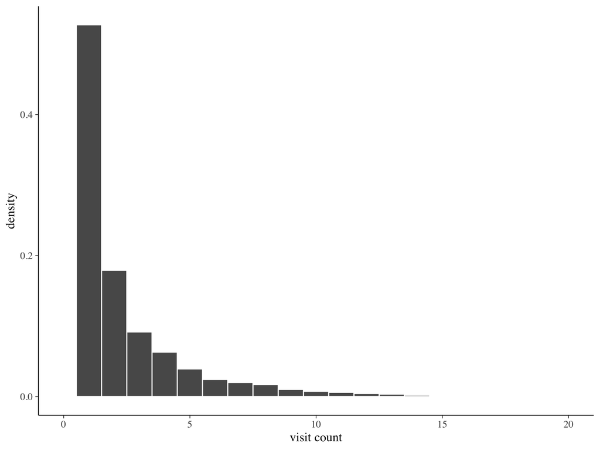

### Plots of HCCs. There are 86 of them here.

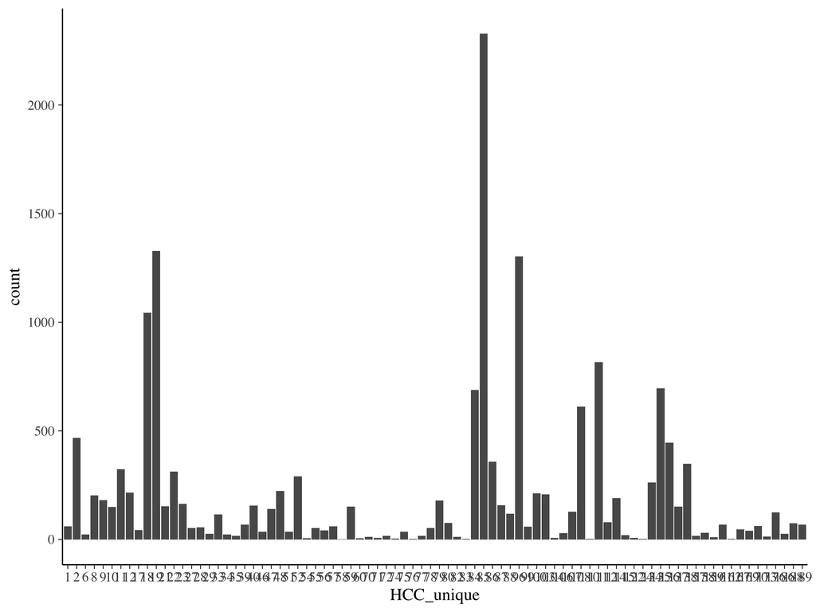

Difficult to see here but the most common is 85, which contains a range of ICD 10 codes beginning with A and I, under the general category of congestive heart failure. HCC 19, “diabetes without complication” and 96, “heart arhythmias”, are also common.

# Counts of patient HCC counts

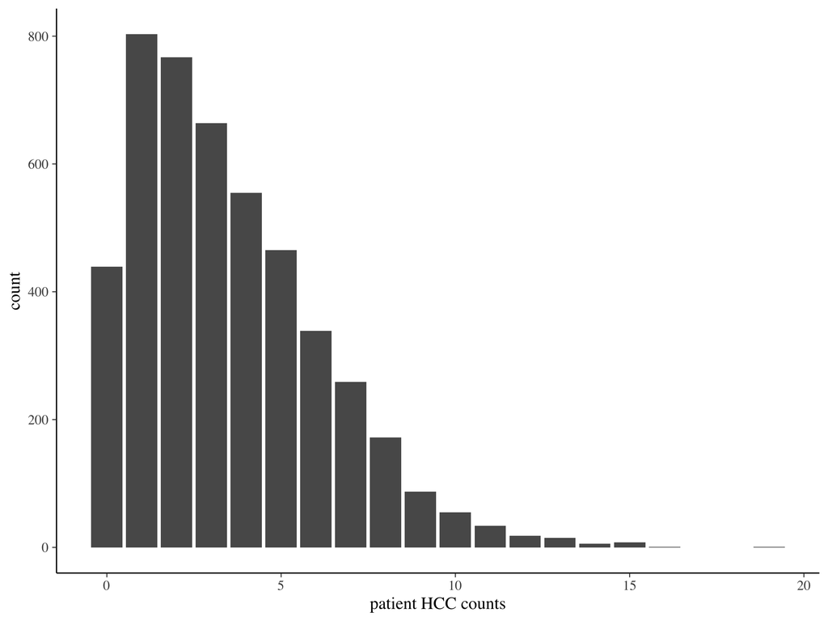

# Modeling HCC counts.

Before we look at `visit` data, we model the number of patient HCCs, `hcc_conds`, using using a Poisson regression, which are often used to model count data.
$$\log \mu_i = \alpha + \beta_1 \times \rm{age}_i + \beta_2 \times \rm{gender}_i \\$$

- $i$ represents the age and gender of the $i^{th}$ patient
- Poisson characterized by a single parameter, the mean, $\mu$, which is simply the average (i.e. the mean) number of hcc counts.

### Other possible Poisson models

For example, define model coefficients for each gender $j$. Here are two examples

$$\log \mu_{i,j} = \alpha_{j} + \beta_{1,j} \times \rm{age}_i \\
\log \mu_{i,j} = \alpha_0 + \alpha_{j} + (\beta_{0} + \beta_{1,j}) \times \rm{age}_i \\$$
These would appropriate if the amount of increase of `hcc_count` with `age` appeared to depend on `gender`. Hierarchical models exploit any group structure but also pool results between groups.

The modeling process estimates the coefficients $\alpha, \beta_1,$ and $\beta_2$. Bayesian methods yield a probability distribution for each of these coefficients. The number of HCCs for a patient is then viewed as a random process with possible outcomes 0, 1, 2, 3,…, each with a specified probability. Generally we write

$$\textrm{hcc_conds}_i \sim \textrm{Poisson}(\mu_i) \\$$

### Example- an “intercept only” model; that is with $\alpha$ but no predictors.

```
# A tibble: 6 × 3
  term     estimate std.error
  <chr>       <dbl>     <dbl>
1 alpha        1.26   0.00783
2 y_rep[1]     3      1.83
3 y_rep[2]     3      1.87
4 y_rep[3]     3      1.86
5 y_rep[4]     3      1.88
6 y_rep[5]     3      1.93
```

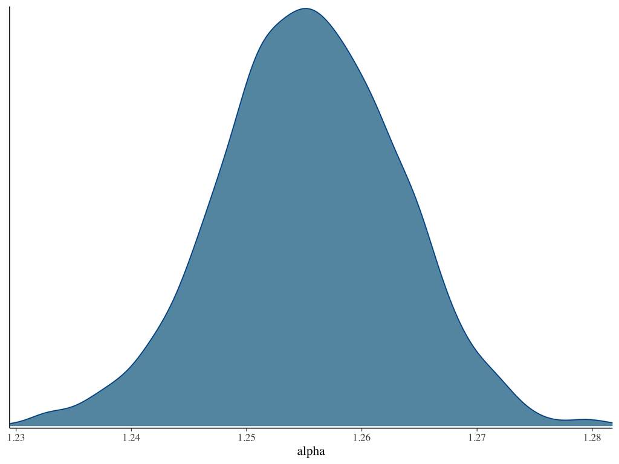

### Intercept-only model

- distribution for $\alpha$.
- distribution of posterior predictive samples of `hcc_conds` - labelled `y_rep[]`.
- contrast to point estimates resulting from frequentist methods.
- 4000 samples of all parameters and predictions
- Note that this is on the log scale, so to get the mean we find

```r
exp(1.26)
```

```
[1] 3.525421
```

which agrees with the mean number of HCCs per patient for this data set, which is about 3.5.

### Post predictive checks

Compare the distribution of `hcc_conds` from the data with those from the posterior samples generated by the model. Here, the former are labeled $y$ and the latter, $y_rep$.

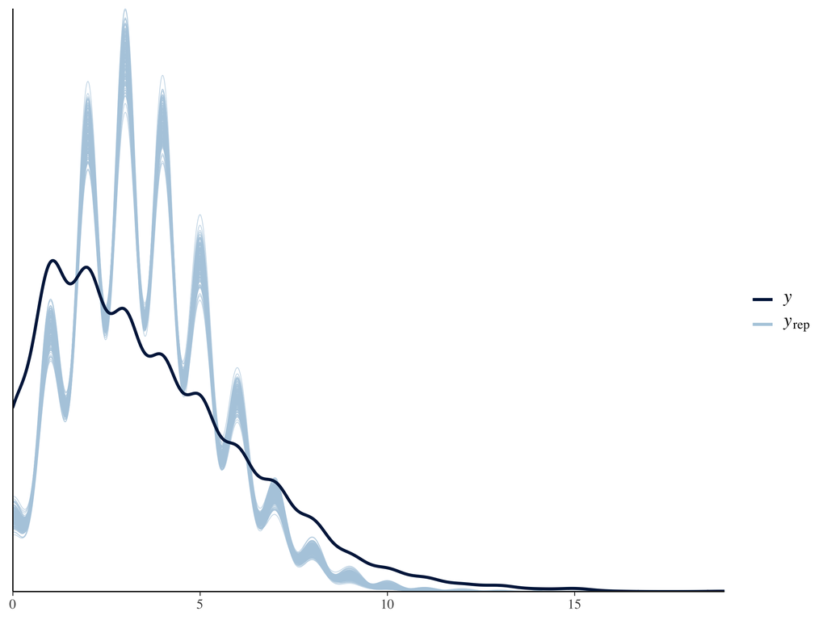

We can see that it is not too good.

- underestimates the number of zeros, and overestimates 2 through 6, and underestimates larger values.
- “underdispersion” is common (as is overdispersion).
- Poisson is characterized by a single parameter, mean = variance

### Negative Binomial model

```
# A tibble: 6 × 3
  term     estimate std.error
  <chr>       <dbl>     <dbl>
1 alpha       1.26     0.0111
2 inv_phi     0.319    0.0132
3 phi         3.14     0.130
4 y_rep[1]    3        2.62
5 y_rep[2]    3        2.67
6 y_rep[3]    3        2.81
```

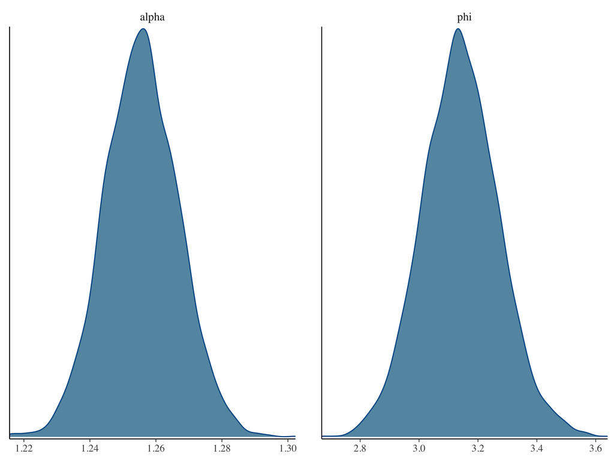

You can see the model estimates an additional shape parameter, $\phi$, which controls the standard deviation.

### Post predictive check

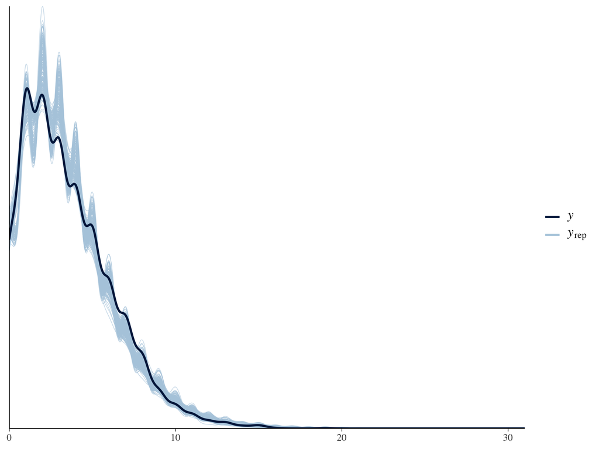

We can see the negative binomial does a much better job. As further check we can how the distribution of proportions for different values of hcc count compares with those in the data. For example about 9.3% percent of the patients had zero `hcc_conds`. We can compare that to the distribution of zeros in the posterior samples generated by the model.

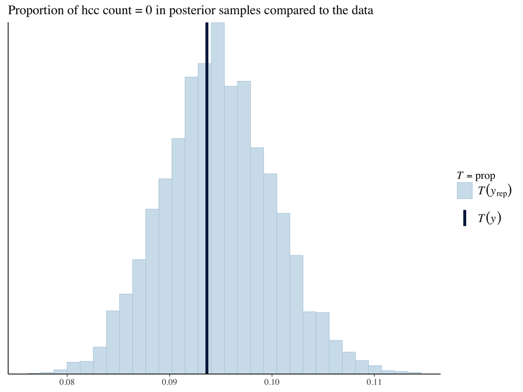

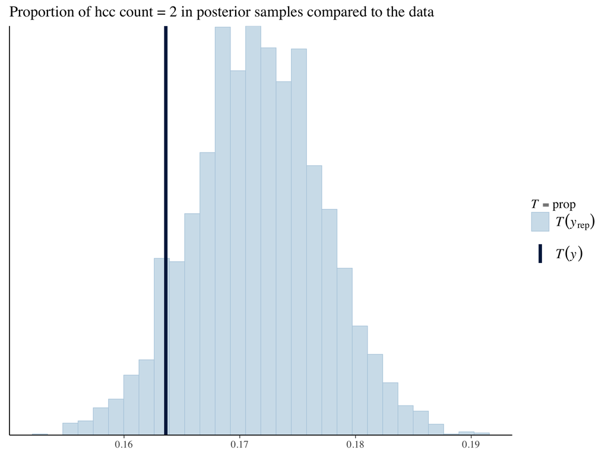

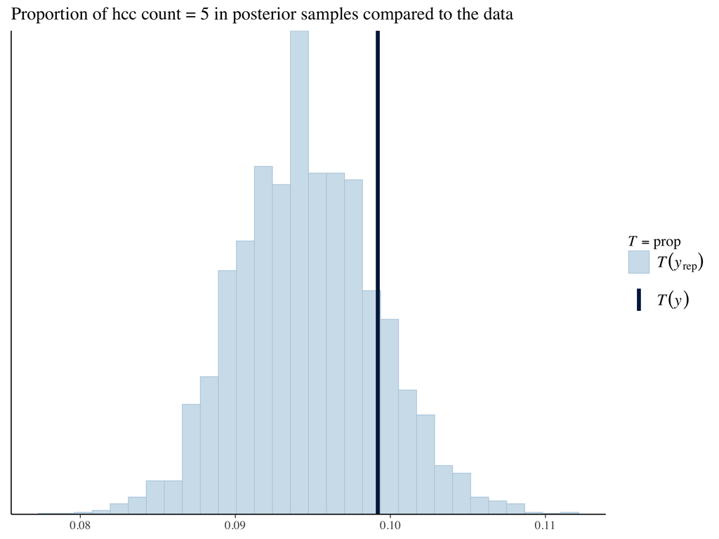

# Modeling `visits`.

Now we try modeling visits with various predictor variables. A real model may have thousands of predictors, but we can illustrate the approach with just one, the hcc counts we just considered. Then we will add fake ibis use data to the model. The visit data is a bit different than the hcc counts as there are no zeros present in the data set that I have. Thus, both Poisson and negative binomial may be problematic. In fact, with some care, truncated versions of these may be used. We do not do this below, yet.

### Poisson model

Recall the distribution of visits

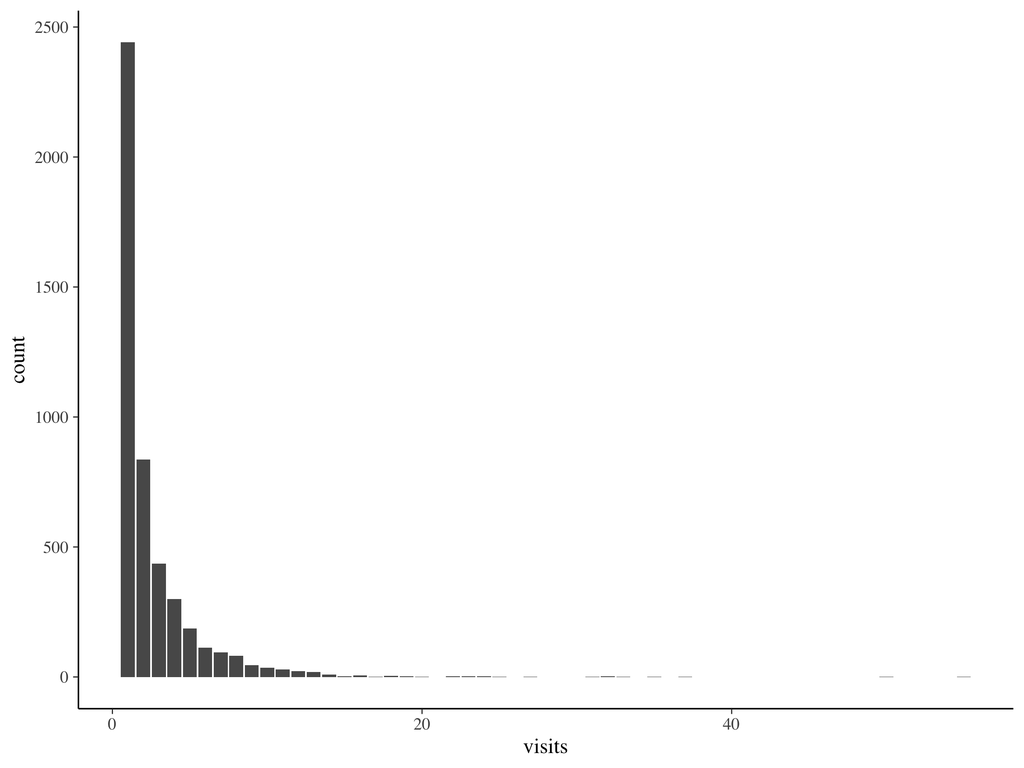

We try the Poisson regression with the single predictor `hcc_counts`. We see there is a weak relationship

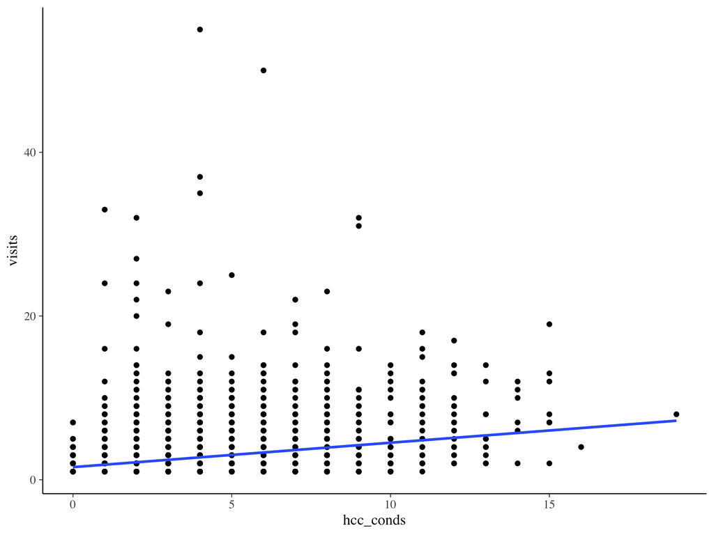

In fact, a non-Bayesian/frequentist Poisson regression will conclude that the relationship is “statistically significant”:

```
# A tibble: 2 × 5
  term        estimate std.error statistic   p.value
  <chr>          <dbl>     <dbl>     <dbl>     <dbl>
1 (Intercept)    0.561   0.0157       35.8 1.80e-280
2 hcc_conds      0.100   0.00294      34.0 6.95e-254
```

### Remarks on interpreting model coefficients

Interpreting the coefficients is not as direct as it is with ordinary linear regression models; that is, with identity link function. Its not too bad here- the link is the log function so the effects are multiplicative. Consider the mean for `hcc_conds`.

```r
exp(0.100)
```

```
[1] 1.105171
```

So with every increase in `hcc_conds`, we get a bit more than a 10% jump in mean number of visits. Interpreting the coefficients is often not so straightforward, depending on the model. Even here, we assume that we are holding other predictors constant, which does not happen in real life.

Bayesian approaches skirt these issues entirely by simply examining the posterior distribution at different levels of the predictors. We will see how this is done.

### The Model

$$\begin{align*}
\textrm{visits}_i & \sim \textrm{Poisson}(\mu_{i}) \\
\log \mu_{i} & = \alpha +\beta \times \textrm{hcc_count}_i \\
\end{align*}$$
There are also priors on the parameters that are part of the model. We skip discussion of that for now but happy to discuss.

### Model results.

Remembering that these values are on the log scale, we see that these result are consistent with the non-bayes.

```
# A tibble: 2 × 3
  term        estimate std.error
  <chr>          <dbl>     <dbl>
1 (Intercept)    0.561   0.0155
2 hcc_conds      0.100   0.00302
```

# Densities for the coefficients

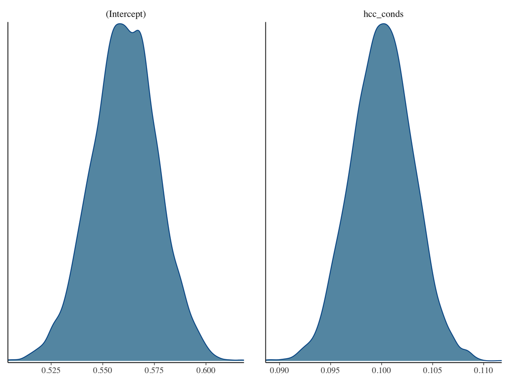

We can easily do things like find the probability that coeffs lie in $any$ given interval. Moreover, we can generate distributions for any statistic computed from the data and parameters.

For example, we can compare the likelihood that a person with 10 `hcc_conds` has more than 4 visits, to that of a person with 5 hcc’s.

$$\frac{P(\rm{vists} > 4 | \rm{hcc} = 10)}{P(\rm{vists} > 4 | \rm{hcc} = 5)}$$

```r
set.seed(84732)
pp <- posterior_predict(vm.2, newdata = data.frame(hcc_conds = c(10, 5))) %>%
    as.data.frame()
mean(pp$"1" > 4)/mean(pp$"2" > 4)
```

```
[1] 3.079179
```

### Posterior check, as we did with previous last models.

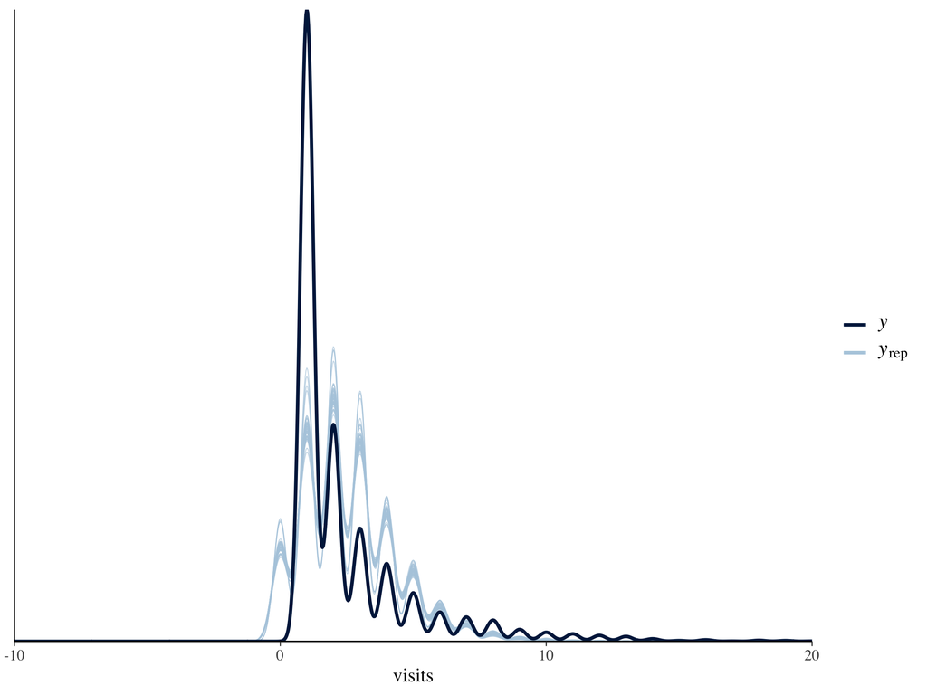

We can see the problem with the zero values, and also the same dispersion issue we saw before. We put this aside for now…

# More fake data

We add fake Ibis indicator variable to our data to represent use of the device or not.

```
Rows: 4,688
Columns: 13
$ PATIENT_NBR <chr> "000000001", "000000002", "000000003", "000000004", "00000…
$ FIN_CLASS   <chr> "C", "CP", "C", "C", "CP", "C", "CP", "C", "C", "C", "C", …
$ data        <list<tibble[,5]>> [<tbl_df[29 x 5]>], [<tbl_df[220 x 5]>], [<tb…
$ HCC_unique  <list> <111, NA, 85, 112>, <59, 85, NA, 96, 111, 186, 107, 23, 1…
$ visits      <int> 2, 18, 2, 2, 2, 2, 2, 2, 1, 1, 4, 2, 7, 1, 2, 4, 1, 1, 1, …
$ hcc_conds   <int> 3, 11, 1, 0, 2, 3, 1, 3, 1, 4, 2, 7, 6, 2, 2, 2, 4, 4, 5, …
$ age         <dbl> 68, 85, 74, 65, 69, 79, 69, 64, 63, 70, 75, 80, 79, 69, 66…
$ gender      <fct> F, F, F, M, F, F, M, F, M, F, M, M, M, F, F, M, F, F, M, F…
$ financial   <ord> 1, 2, 3, 2, 2, 3, 2, 3, 2, 1, 3, 1, 3, 1, 3, 3, 1, 3, 3, 3…
$ wt          <dbl> 0.65, 0.45, 0.65, 0.65, 0.65, 0.65, 0.65, 0.65, 0.65, 0.65…
$ `1:n()`     <int> 1, 2, 3, 4, 5, 6, 7, 8, 9, 10, 11, 12, 13, 14, 15, 16, 17,…
$ ibis        <dbl> 1, 1, 1, 1, 0, 1, 1, 1, 1, 1, 1, 0, 0, 1, 1, 1, 0, 1, 1, 1…
$ ibis_idx    <dbl> 2, 2, 2, 2, 1, 2, 2, 2, 2, 2, 2, 1, 1, 2, 2, 2, 1, 2, 2, 2…
```

### Distribution of ibis use

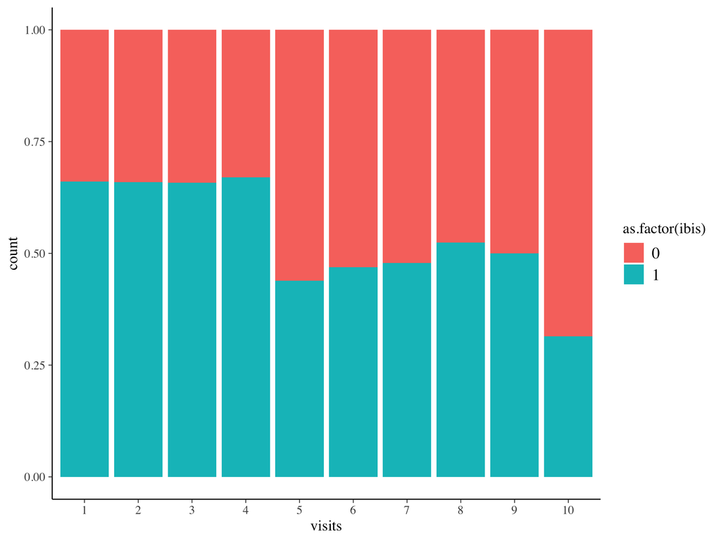

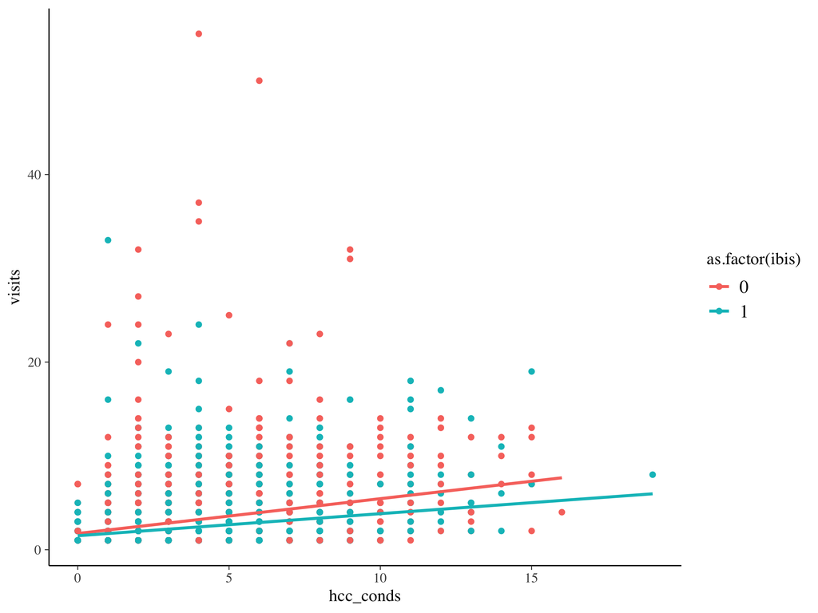

We can see the slight interaction between Ibis and hcc counts as evidenced by the different slopes for the linear regression lines in each case

We can also check the overall mean of `visits` with `ibis` vs not.

```
# A tibble: 2 × 2
   ibis ave_visits
  <dbl>      <dbl>
1     0       3.11
2     1       2.29
```

It turns out the difference is “statistically significant” in the NHST sense.

```
    One-way analysis of means (not assuming equal variances)

data:  ibis_fake$visits and ibis_fake$ibis
F = 62.407, num df = 1, denom df = 2488, p-value = 4.155e-15
```

### The model is now

$$\begin{align*}
\textrm{visits}_i & \sim \textrm{Poisson}(\mu_{i}) \\
\log \mu_{i} & = \alpha +\beta_{hcc} \times \textrm{hcc_count}_i +\beta_{ibis} \times \textrm{ibis}_i \\
\end{align*}$$

### As before, we can check the frequentist Poisson regression model

```
# A tibble: 3 × 5
  term        estimate std.error statistic   p.value
  <chr>          <dbl>     <dbl>     <dbl>     <dbl>
1 (Intercept)    2.08    0.0192       38.2 0
2 ibis           0.764   0.0183      -14.7 6.69e- 49
3 hcc_conds      1.10    0.00294      32.9 8.59e-238
```

And now the Bayesian model

```r
tidy(p.2.rstn, exponentiate = TRUE)
```

[output not shown]

```r
exp(0.733)
```

```
[1] 2.081315
```

```r
exp(-0.270)
```

```
[1] 0.7633795
```

```r
exp(0.097)
```

```
[1] 1.10186
```

Again agreeing with the point estimates above.

### Examining `visits` across different strata of the predictors

Patients with 5 hcc conditions.

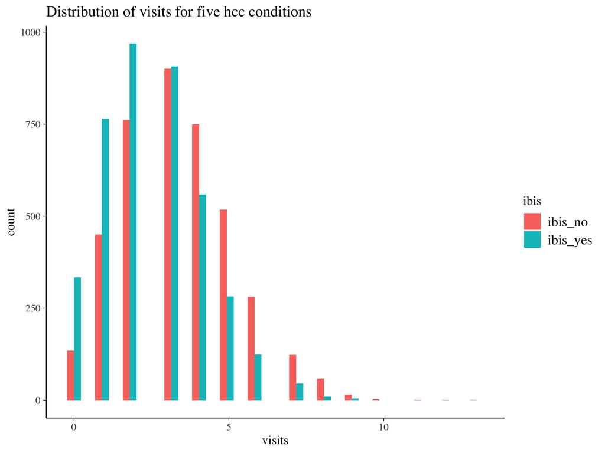

### Likelihood ratios

We can see that after three visits the non users dominate. We can quantify this with the likelihood ratio

$$\frac{P(\rm{vists} > 3 | \rm{hcc} = 5, \rm{ibis} = no)}{P(\rm{vists} > 3 | \rm{hcc} = 5, \rm{ibis} = yes)}$$

```r
mean(pp$ibis_no > 3)/mean(pp$ibis_yes > 3)
```

```
[1] 1.709268
```

So non-users with five hcc are about 71% more likely to have more than three visits. As a remark, we stress that this statistic is itself a random variable and our value is but one outcome. So in practice we would simulate it many times and generate a distribution. Then we could generate credible intervals and p-value type probabilities for this likelihood

If we repeat the above with ten hcc conditions we obtain the ratio

```r
mean(pp2$ibis_no > 3)/mean(pp2$ibis_yes > 3)
```

```
[1] 1.327944
```

That the likelihood ratio seems to be dependent on the the number of hcc suggests that there is an interaction between `hcc_count` and `ibis`. We saw that above in the plot of `visits` vs `hcc_count`, stratified by `ibis`.

# Things to consider

- More predictors
- ordering of the HCC

# Things to consider

- Hierarchical models. These take advantage of group structure (all women, all Ibis users, etc) and model each separately, with partial pooling for the entire population. For example, with group indicator $j$ the model might look like

$$\begin{align*}
\textrm{visits}_i & \sim \textrm{Poisson}(\mu_{i}) \\
\log \mu_{i,j} & = \alpha_j +\beta_{hcc, j} \times \textrm{hcc_count}_i +\beta_{ibis, j} \times \textrm{ibis}_i \\
\end{align*}$$

# Things to consider

- propensity score and inverse probability of treatment weighting methods for comparison populations. Such techniques match patients with similar profiles to control confounding and thus mimic randomized controlled studies.
- other diagnostic/condition categorise- DRG, ACG, CRG, etc.
- likelihood encodings for ICD 10 or for condion categories
- truncated distributions. To handle non zero data.
- That hospital or ER data will not have zero values is itself a problem as it is selection bias.
- interaction terms
- Other model approaches- tree-based, neural nets, etc.